# RSelenium & Web Scraper Chrome to gather data

Pablo Ugarte

2017-09-21

# Intro

> In this post, we scrape data and data wrangle to get a picture of type oj jobs offered in the expansion website.

# Libraries

Overall, we are going to use the following R packages:

```r
library(XML) # For web scraping
library(rvest) # For web scraping
library(tidyverse) # Data wrangling packages gather, spread...
library(lubridate) # To work with dates
library(hrbrthemes) # Aesthetic defaults for ggplot2 charts
library(stringr) # For manipulating strings
```

One way would be to make vector of all the urls you are interested in and then use sapply.

To convert a list of data frames into one data frame we use the dplyr::rbind_all(). This will do the trick ;) [^2].

```r
pages <- 0:5
urls <- paste0("http://www.expansionyempleo.com/buscar-trabajo-empleo/cid/3BC18A08D9BB661C9B65C93203B654EF/canal/0/pagenumber/",pages)

get_table <- function(url) {
  url %>%
    read_html() %>%
    html_nodes(xpath = '//*[@id="mytable"]') %>%
    html_table()
}

results <- sapply(urls, get_table)
results <- rbind_all(results)
View(results)
```

However, I am getting an error when I increase the number of pages to more than 5. So I decided to use the Web Scraper Chrome extension [^3] and download the file to csv.

```r
expansion2 <- read_csv("~/Documents/R Working Directory/Blog/First/content/post/expansion2.csv")
```

# Cleansing

We now we can start our analysis.

The dataframe has 5 columns:

- Fecha (date - format %d/%m)
- Cargo (job)
- Empresa (company/headhunter)
- Vacantes (vacancies)
- Zona (city)

Expansion is the main financial newspaper in Spain and hence quality of the jobs posted are meant to be above average (in terms of salary and job responsabilities).

Let’s go into more detail and get a sense of the proportion of “bad quality jobs” out of the total.

We first convert selected columns of the dataframe to lower case. We will aso clean text from punctutation using R Base gsub.

```r
expansion2 <- expansion2 %>% mutate(Cargo = tolower(Cargo)) %>% mutate(Empresa = tolower(Empresa)) %>% mutate(Zona = tolower(Zona))
expansion2$Cargo <- gsub(pattern="[[:punct:]]", expansion2$Cargo, replacement=" ")
```

We can find out the jobs (Cargo) that contain ‘prácticas’ or ‘beca’ (or related like becario) by using ‘str_detect’ function from ‘stringr’ package.

We use it inside ‘mutate’ command so that it will return TRUE or FALSE. And then calculate the percentage we seek.

```r
# Create a vector of a list of names I want to extract into a new column in the dataframe
extract <- c("beca","becario", "prácticas", "práctica", "practicas")

#  str_detect only accepts a length-1 pattern so we use paste(..., collapse = '|')
expansion2 <- expansion2 %>% mutate(subpar = str_detect(expansion2$Cargo, paste(extract, collapse = '|')))

# Lets's change the following subpar’ names using ‘recode’ function from dplyr package
expansion2 <- expansion2 %>%
  mutate(subpar=replace(subpar, subpar==FALSE, "Good quality")) %>%
  mutate(subpar=replace(subpar, subpar==TRUE, "Bad quality"))
```

Now, let’s say we want to understand what are the percentage of low quality vacancies/jobs out of the total.

```r
qualityjobs <- expansion2 %>%
  group_by(subpar) %>%
  summarise (n = sum(Vacantes)) %>%
  mutate(freq = n / sum(n))
View(expansion2)
View(qualityjobs)
```

Let’s plot the above.

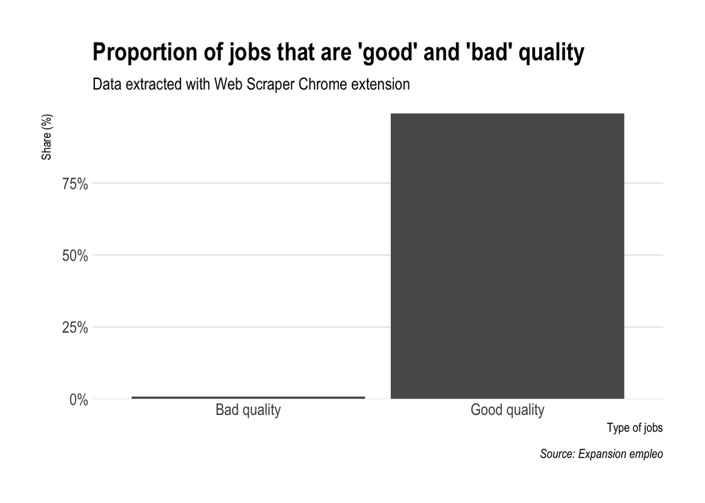

```r
ggplot(data=qualityjobs, aes(subpar, freq)) +
geom_col() +
scale_y_percent() +
labs(x="Type of jobs", y="Share (%)",
       title="Proportion of jobs that are 'good' and 'bad' quality",
       subtitle="Data extracted with Web Scraper Chrome extension",
       caption="Source: Expansion empleo") +
theme_ipsum(grid="Y")
```

Now, let’s see which city offers more bad quality jobs. We will select the top 5 cities for each type of quality job based on frequency (in % terms of total by that city).

```r
qualityjobszona <- expansion2 %>%
  group_by(Zona, subpar) %>%
  summarise (n = sum(Vacantes)) %>%
  mutate(freq = n / sum(n)) %>%
  filter(n > 10) %>%
  filter(subpar == "Bad quality") %>%
  arrange(desc(freq)) %>%
  top_n(5, freq)
View(qualityjobszona)
```

Let’s plot the above.

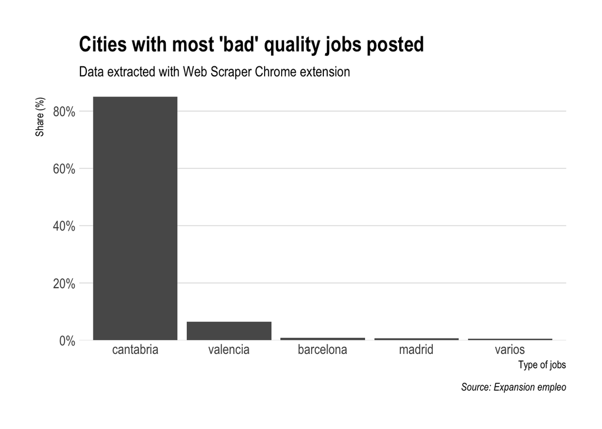

```r
ggplot(data=qualityjobszona, aes(reorder(Zona, -freq), freq)) +
geom_col() +
scale_y_percent() +
labs(x="Type of jobs", y="Share (%)",
       title="Cities with most 'bad' quality jobs posted",
       subtitle="Data extracted with Web Scraper Chrome extension",
       caption="Source: Expansion empleo") +
theme_ipsum(grid="Y")
```

In this article, we have briefly explored the web scraping of public data and shown some of the R’s power for data analysis.

[^1]: Link1 (https://stackoverflow.com/questions/40140133/scraping-tables-on-multiple-web-pages-with-rvest-in-r)
[^2]: Link2 (https://stackoverflow.com/questions/2851327/convert-a-list-of-data-frames-into-one-data-frame)
[^3]: Lik3 (http://webscraper.io/)